# Group Work

## 7. Variable importance

Which design features drive the classification? We pull importance from the random forest — it ties straight back to the EDA story.

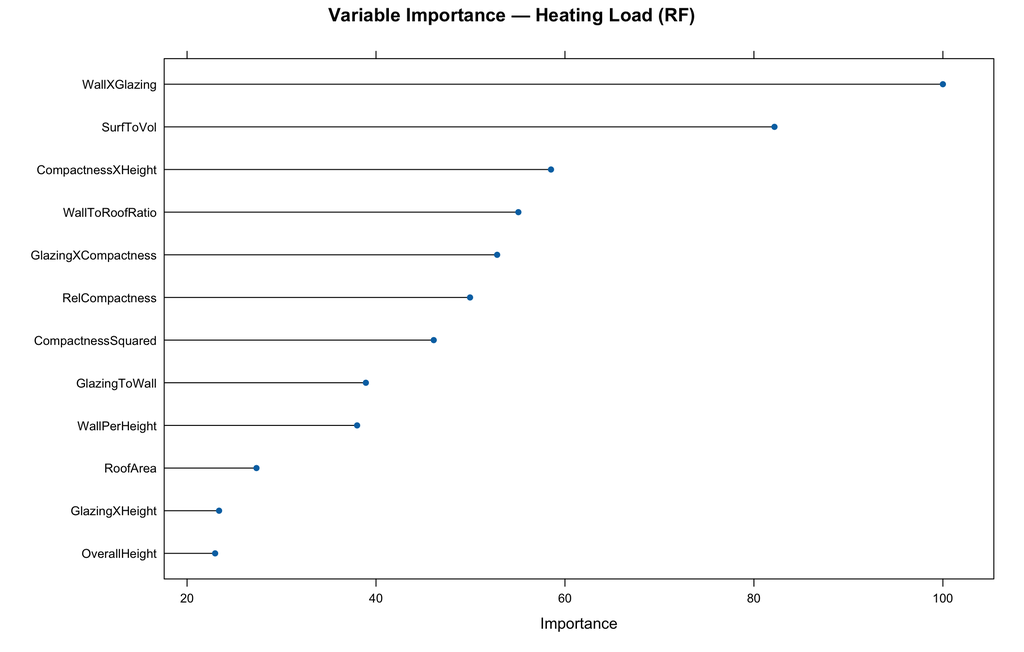

```r
vi_hl <- varImp(m_rf_HL)
plot(vi_hl, top = 12, main = "Variable Importance — Heating Load (RF)")
```

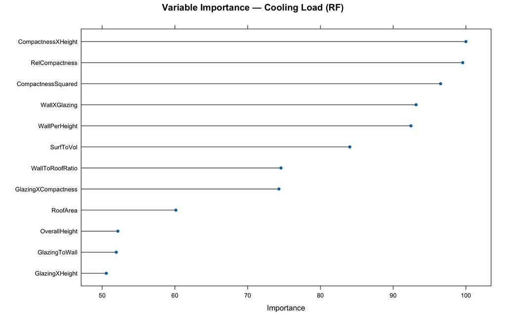

```r
vi_cl <- varImp(m_rf_CL)
plot(vi_cl, top = 12, main = "Variable Importance — Cooling Load (RF)")
```

## 8. Wrap-up

```r
summary_tab <- bind_rows(
  hl_results %>% mutate(Target = "Heating Load") %>% arrange(desc(AUC)) %>% slice(1),
  cl_results %>% mutate(Target = "Cooling Load") %>% arrange(desc(AUC)) %>% slice(1)
) %>%
  dplyr::select(Target, Model, AUC, Accuracy, Precision)

cat("  CLASSIFICATION — BEST MODEL PER TARGET\n")
```

```
##   CLASSIFICATION — BEST MODEL PER TARGET
```

```r
print(summary_tab, row.names = FALSE)
```

```
##        Target   Model       AUC  Accuracy Precision
##  Heating Load XGBoost 0.9985846 0.9671053 0.9667499
##  Cooling Load XGBoost 0.9951691 0.9407895 0.9419401
```

**Actionable Insights for Policy Makers:** By categorizing energy requirements into “Low”, “Medium”, and “High” loads, we’ve developed classifiers capable of flagging inefficient buildings with high precision and strong ROC/AUC scores. Flexible models like Random Forest and XGBoost performed exceptionally well. The variable importance analysis reveals that raw metrics like overall height alone are not the primary drivers. Instead, the **interaction between building compactness and height** (`CompactnessXHeight`), as well as the **combined wall-to-glazing exposure** (`WallXGlazing` and `SurfToVol`), are the most critical factors for distinguishing whether a building will fall into a Low, Medium, or High load category.

**Policy Recommendation:** Rather than simply capping building height, new building codes must adopt a holistic geometric approach. Zoning regulations should enforce strict limits on the ratio of glazing for large exposed wall areas, and mandate compensatory insulation for highly non-compact, tall buildings to reliably prevent them from entering the “High Load” category and straining grid resources.